# Final Prep

## Chi-squared

CHi-square test in R is a statistical method which used to determine if two categorical variables have a significant correlation between them. Therefore, a significant p-value means that they are significantly correlated, and non-significant p-value means that they are independent from each other.

2. Is being treated with D-penicillamine dependent or independent from sex?

```r
pbc_b <- pbc |>
  filter(!is.na(trt)) |>
  select(sex, trt) |>
  mutate(trt = as.character(trt)) |>
  group_by(sex, trt) |>
  summarise(dp = n()) |>
  ungroup() |>
  pivot_wider(names_from = trt, values_from = dp) |>
  as.data.frame()

chisq.test(pbc_b[-1])
```

```
##
##  Pearson's Chi-squared test with Yates' continuity correction
##
## data:  pbc_b[-1]
## X-squared = 0.64689, df = 1, p-value = 0.4212
```

```
From the result, we conclude that being treated with D-pencillamine is independent from sex.
```

3. Is having spiders independent from disease stage?

```r
pbc_c <- pbc |>
  select(spiders, stage) |>
  filter(!(is.na(spiders) | is.na(stage))) |>
  group_by(stage, spiders) |>
  summarise(sp = n()) |>
  pivot_wider(names_from = spiders, values_from = sp) |>
  as.data.frame() |>
  print()
```

```
##   stage  0  1
## 1     1 15  1
## 2     2 58  9
## 3     3 90 30
## 4     4 59 50
```

```r
chisq.test(pbc_c[-1], simulate.p.value = TRUE)
```

```
##
##  Pearson's Chi-squared test with simulated p-value (based on 2000
##  replicates)
##
## data:  pbc_c[-1]
## X-squared = 27.993, df = NA, p-value = 0.0004998
```

```
As one of the values in the dataframe is quite small, chi-squared test may yield an inaccurate result. To avoid that, we set simulate.p.value = TRUE which computes p-values by Monte Carlo simulation. From the result, we conclude that having spiders is dependent on disease stage.
```

4. Is there a significant different in cholesterol levels between people with or without an enlarged liver (hepatomegaly)?

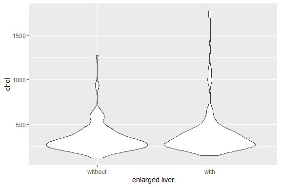

```
Well the data does not seem normally distributed, and as we are not so concerned with the difference in mean, we should consider wilcox test.
```

```r
pbc_d <- pbc |>
  select(hepato, chol) |>
  filter(!(is.na(hepato) | is.na(chol)))


pbc_d |>
  ggplot(aes(as.character(hepato), chol))+
  geom_violin() +
  scale_x_discrete(label = c("without", "with")) +
  labs(x = "enlarged liver")
```

```r
wo <- filter(pbc_d, hepato == 0)$chol
w <- filter(pbc_d, hepato == 1)$chol
wilcox.test(wo,w)
```

```
##
##  Wilcoxon rank sum test with continuity correction
##
## data:  wo and w
## W = 8852.5, p-value = 0.07858
## alternative hypothesis: true location shift is not equal to 0
```

```
From the result, there is no significant difference in cholesterol levels between people with or without an enlarged liver, which is counter-intuitive. If we have used a t-test, we would have gotten a significant result. But since the distribution is not normal, we should stick to the original plan …
```

### Question 6

A woman claims to be able to tell if tea is prepared with milk added to the cup first or added after the tea was poured.

She tastes 20 cups of tea (10 with the milk poured in first and 10 with the milk poured in after) …. and correctly guesses that the milk has been poured first 8 times and that the milk has been poured in last 6 times.

What is the null and alternative hypothesis for this experiment?

```
The null hypothesis: Her result is out of random choice and there is no relationship between her choice and actual order.
The alternative hypothesis: She can correctly identify which is poured first.
```

Can she justify her claim to be able to do this ?

```
No she cannot. We have set our signifncance level \alpha to be 0.05 for this problem set. Under this restraint, her trial of 20 times should yield at most one error to call it significant. Since she wrong-guessed 6 times, we fail to reject the null hypothesis.
```

## type II error

### Question 7

1. What is the relationship between power and type II errors?

   Power equals to 1 minus the probability of having type II errors. Power is the ability of a test to correctly reject false negatives. Type II errors are false negatives, i.e., when the alternative hypothesis is true but we fail to reject the null hypothesis.
2. How many replicates do I need to perform to achieve 80% power to detect a change in the mean between two conditions of 2? (assume the data is normally distributed so t-tests apply). I ran a pilot experiment and collected the following data.

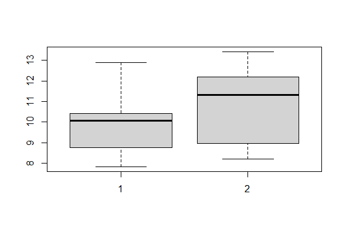

```r
treatment = c( 7.835008, 12.887306, 10.427879,  8.749182, 10.075484)
control = c(12.182948,  8.972897,  8.215060, 13.421730, 11.325449)
boxplot(treatment, control)
```

```r
t_sd <- sd(treatment)
c_sd <- sd(control)
```

```r
# # prepare an empty vector for storing power
# power <- c()
# # check the sample size from 2 to 30
# for(i in 2:30){
#   # prepare an empty vector for replication
#   power_rep <- c()
#   # replicate for 100 times
#   for (j in 1:100){
#     # prepare an empty vector to store simulation
#     result <- c()
#     # simulation
#     for (k in 1:1000){
#       # two samples, different standard deviation
#       # difference in mean of 2
#       x <- rnorm(i, 2, t_sd)
#       y <- rnorm(i, 0, c_sd)
#       # p-value
#       result = c(result, t.test(x, y, var.equal = FALSE)$p.value)
#     }
#     # calculate false negatives
#     z <- 1 - sum(result > 0.05) / length(result)
#     # store power
#     power_rep <- c(power_rep, z)
#   }
#   # calculate the mean of power
#   m_power_rep <- mean(power_rep)
#   # append
#   power <- c(power, m_power_rep)
# }
#
# # plot
# plot(power, type = "lm", xlab = "sample size")
# abline(h = 0.8, col = "red")
```

```r
#power
```

[output not shown]

# Problem set 3

## Part 1 - Diet

The data set (Diet_R.csv) contains information on 78 people using one of three diets, and contains information on their weight before starting the diet and their weight 6 weeks after being on a specific diet.

Person Participant number  
gender Gender, 1 = male, 0 = female  
Age Age (years) Height Height (cm) preweight Weight before the diet (kg) Diet Diet  
weight6weeks Weight after 6 weeks (kg)

```r
data = read.csv("Diet_R.csv") |>
  mutate(weight_loss = weight6weeks - pre.weight)
```

### Q1: Does diet affect weight loss?

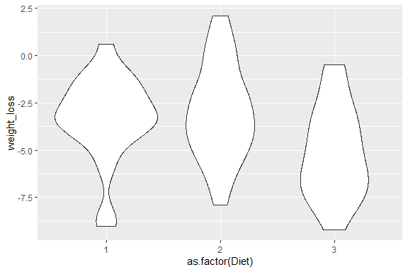

```r
# first of all, visualization.
data |>
  select(Diet, weight_loss) |>
  ggplot(aes(as.factor(Diet), weight_loss)) +
  geom_violin()
```

```r
q1 <- data |>
  # select columns
  select(Diet, weight_loss) |>
  # remove na values
  filter(!(is.na(Diet) | is.na(weight_loss))) |>
  mutate(Diet = as.factor(Diet))

# perform one-way anova
model_q1<- aov(weight_loss ~ Diet, data = q1)
summary(model_q1)
```

```
##             Df Sum Sq Mean Sq F value  Pr(>F)
## Diet         2   71.1   35.55   6.197 0.00323 **
## Residuals   75  430.2    5.74
## ---
## Signif. codes:  0 '***' 0.001 '**' 0.01 '*' 0.05 '.' 0.1 ' ' 1
```

The p-value of 0.00324 is less than 0.05 (alpha), we reject the null hypothesis and conclude that the Diet type is significantly affecting the weight loss. If we want to see which diet is affecting the weight loss, we could fit a linear model, but this time I just did a one-way anova.

### Q2: Is there an effect of diet or gender on weight loss?

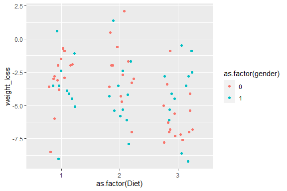

```r
data |>
  filter(!(is.na(Diet)|is.na(gender) | is.na(weight_loss))) |>
  ggplot(aes(as.factor(Diet), weight_loss, color = as.factor(gender))) +
  geom_jitter(width=0.25)
```

```r
# two-way anova
q2 <- data |>
  # select three columns for simplicity
  select(Diet, gender, weight_loss) |>
  # remove NAs
  filter(!(is.na(Diet) | is.na(gender) | is.na(weight_loss))) |>
  # change gender column from int to fctr
  mutate(
    Diet = as.factor(Diet),
    gender = as.factor(gender)
  )

model_q1_lm <- lm(weight_loss ~ Diet, data = q1)
summary(model_q1_lm)
```

```
##
## Call:
## lm(formula = weight_loss ~ Diet, data = q1)
##
## Residuals:
##     Min      1Q  Median      3Q     Max
## -5.7000 -1.6519 -0.1759  1.3815  5.1259
##
## Coefficients:
##             Estimate Std. Error t value Pr(>|t|)
## (Intercept)  -3.3000     0.4889  -6.750 2.72e-09 ***
## Diet2         0.2741     0.6719   0.408  0.68449
## Diet3        -1.8481     0.6719  -2.751  0.00745 **
## ---
## Signif. codes:  0 '***' 0.001 '**' 0.01 '*' 0.05 '.' 0.1 ' ' 1
##
## Residual standard error: 2.395 on 75 degrees of freedom
## Multiple R-squared:  0.1418, Adjusted R-squared:  0.1189
## F-statistic: 6.197 on 2 and 75 DF,  p-value: 0.003229
```

```r
# two-way anova
model_q2 <- aov(weight_loss ~ Diet + gender, data = q2)
summary(model_q2)
```

```
##             Df Sum Sq Mean Sq F value  Pr(>F)
## Diet         2   60.5  30.264   5.312 0.00705 **
## gender       1    0.2   0.169   0.030 0.86387
## Residuals   72  410.2   5.698
## ---
## Signif. codes:  0 '***' 0.001 '**' 0.01 '*' 0.05 '.' 0.1 ' ' 1
```

```r
model_q2_lm <- lm(weight_loss ~ Diet + gender, data = q2)
summary(model_q2_lm)
```

```
##
## Call:
## lm(formula = weight_loss ~ Diet + gender, data = q2)
##
## Residuals:
##     Min      1Q  Median      3Q     Max
## -5.6445 -1.6941 -0.1218  1.4018  5.3262
##
## Coefficients:
##             Estimate Std. Error t value Pr(>|t|)
## (Intercept) -3.26038    0.53890  -6.050  5.9e-08 ***
## Diet2        0.03422    0.68226   0.050  0.96014
## Diet3       -1.84551    0.66982  -2.755  0.00742 **
## gender1     -0.09508    0.55258  -0.172  0.86387
## ---
## Signif. codes:  0 '***' 0.001 '**' 0.01 '*' 0.05 '.' 0.1 ' ' 1
##
## Residual standard error: 2.387 on 72 degrees of freedom
## Multiple R-squared:  0.1289, Adjusted R-squared:  0.09259
## F-statistic: 3.551 on 3 and 72 DF,  p-value: 0.01855
```

For Diet, we know that it is significantly affecting the weight loss, but the look at summary of `model_q1_lm` reveals that the model only explains about 12% of the variance. It is not a good model either. This tells us that even though different diets results in different weight loss, diet is not everything.

### Q3: Is there an interaction between diet or gender on weight loss?

```r
q3 <- data |>
  select(Diet, weight_loss, gender) |>
  filter(!(is.na(Diet) | is.na(weight_loss) | is.na(gender)))

model_q3 <- aov(weight_loss ~ as.factor(Diet) * gender, data = q3)
summary(model_q3)
```

```
##                        Df Sum Sq Mean Sq F value  Pr(>F)
## as.factor(Diet)         2   60.5  30.264   5.629 0.00541 **
## gender                  1    0.2   0.169   0.031 0.85991
## as.factor(Diet):gender  2   33.9  16.952   3.153 0.04884 *
## Residuals              70  376.3   5.376
## ---
## Signif. codes:  0 '***' 0.001 '**' 0.01 '*' 0.05 '.' 0.1 ' ' 1
```

### Q4: Which diet is best for losing weight?

## interaction plot

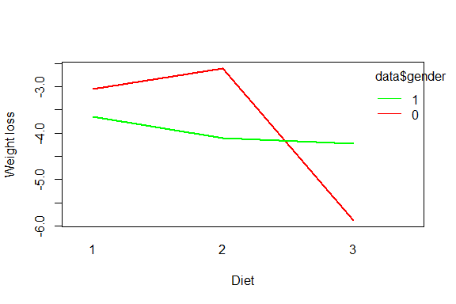

```r
interaction.plot(
  x.factor = data$Diet,
  response = data$weight_loss,
  trace.factor = data$gender,
  col = c("red", "green"),
  fun = mean,
  xlab = "Diet",
  ylab = "Weight loss",
  lty = 1,
  lwd = 2
)
```

```r
data |>
  group_by(Diet) |>
  mutate(Diet = as.factor(Diet)) |>
  summarize(count = n())
```

```
## # A tibble: 3 x 2
##   Diet  count
##   <fct> <int>
## 1 1        24
## 2 2        27
## 3 3        27
```

```r
library(DescTools)
#ScheffeTest(model_q3)
```

```r
TukeyHSD(aov(weight_loss ~ as.factor(Diet) * as.factor(gender), data = data), ordered = TRUE)
```

```
##   Tukey multiple comparisons of means
##     95% family-wise confidence level
##     factor levels have been ordered
##
## Fit: aov(formula = weight_loss ~ as.factor(Diet) * as.factor(gender), data = data)
##
## $`as.factor(Diet)`
##         diff        lwr      upr     p adj
## 1-3 1.848148  0.2905393 3.405757 0.0160200
## 2-3 1.880148  0.3391199 3.421176 0.0128543
## 2-1 0.032000 -1.5546577 1.618658 0.9987150
##
## $`as.factor(gender)`
##           diff        lwr     upr     p adj
## 0-1 0.09502529 -0.9751891 1.16524 0.8599508
##
## $`as.factor(Diet):as.factor(gender)`
##              diff        lwr      upr     p adj
## 3:1-3:0 1.6466667 -0.9846191 4.277952 0.4513580
## 2:1-3:0 1.7709091 -0.9260048 4.467823 0.3965102
## 1:1-3:0 2.2300000 -0.5436187 5.003619 0.1863470
## 1:0-3:0 2.8300000  0.3052886 5.354711 0.0191170
## 2:0-3:0 3.2728571  0.7481458 5.797569 0.0040103
## 2:1-3:1 0.1242424 -2.7117126 2.960197 0.9999949
## 1:1-3:1 0.5833333 -2.3256625 3.492329 0.9915569
## 1:0-3:1 1.1833333 -1.4893925 3.856059 0.7855223
## 2:0-3:1 1.6261905 -1.0465354 4.298916 0.4833188
## 1:1-2:1 0.4590909 -2.5093998 3.427582 0.9975014
## 1:0-2:1 1.0590909 -1.6782698 3.796452 0.8656520
## 2:0-2:1 1.5019481 -1.2354126 4.239309 0.5963201
## 1:0-1:1 0.6000000 -2.2129628 3.412963 0.9887997
## 2:0-1:1 1.0428571 -1.7701056 3.855820 0.8852416
## 2:0-1:0 0.4428571 -2.1250148 3.010729 0.9958151
```

### Q5: Does age have any role in weight loss?

```r
q5 <- lm(weight_loss ~ Age, data = data)
summary(q5)
```

```
##
## Call:
## lm(formula = weight_loss ~ Age, data = data)
##
## Residuals:
##     Min      1Q  Median      3Q     Max
## -5.3679 -1.6764  0.2595  1.7038  5.8717
##
## Coefficients:
##             Estimate Std. Error t value Pr(>|t|)
## (Intercept) -4.43570    1.20114  -3.693 0.000415 ***
## Age          0.01509    0.02977   0.507 0.613683
## ---
## Signif. codes:  0 '***' 0.001 '**' 0.01 '*' 0.05 '.' 0.1 ' ' 1
##
## Residual standard error: 2.564 on 76 degrees of freedom
## Multiple R-squared:  0.00337,    Adjusted R-squared:  -0.009744
## F-statistic: 0.257 on 1 and 76 DF,  p-value: 0.6137
```

The summary p-value of 0.61, which suggests no significant difference. Hence, we fail to reject the null hypothesis and conclude that there is no evidence that age affects the weight loss. The model explains almost nothing about the distribution, as can be seen in the R-squared value.

We can also visualize this, the scattered plot affirms that there is no linear relationship.

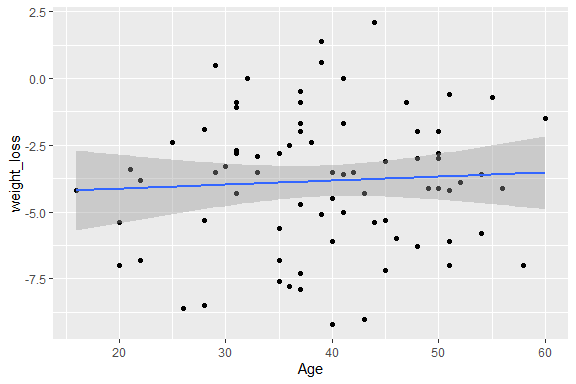

```r
data |>
  select(Age, weight_loss) |>
  filter(!(is.na(Age) | is.na(weight_loss))) |>
  ggplot(aes(Age, weight_loss)) +
  geom_point() +
  geom_smooth(
    formula = y ~ x,
    method = 'lm'
  )
```

## Part 2

The file depression.csv contains the results of a study looking at the effect of treatment on depression.

Hospt: The patient’s hospital (1, 2, 3, 5, or 6) Treat: The treatment received by the patient (Lithium, Imipramine, or Placebo) Outcome: Whether or not a recurrence occurred during the patient’s treatment (Recurrence or No Recurrence) Time: Either the time (days) till recurrence, or if no recurrence, the length (days) of the patient’s participation in the study. AcuteT: The time (days) that the patient was depressed prior to the study. Age: The age of the patient in years, when the patient entered the study. Gender: The patient’s gender (1 = Female, 2 = Male)

```r
data = read.delim("depression.csv", sep=",")
```

### Q6: Is there any association between treatment and outcome?

```r
q6 <- data |>
  filter(!(is.na(Treat) | is.na(Outcome))) |>
  select(Treat, Outcome) |>
  group_by(Treat, Outcome) |>
  summarise(num = n()) |>
  pivot_wider(names_from = Outcome, values_from = num)

chisq.test(q6[-1])
```

```
##
##  Pearson's Chi-squared test
##
## data:  q6[-1]
## X-squared = 12.959, df = 2, p-value = 0.001534
```

Since this question is asking about the association between outcome and treatment, we can simply run a chi-squared test. The p-value of 0.001 suggests that outcome is dependent on the treatment.

Or, as the independent variable is a discrete/binomial variable, we can choose to make a logistic regression model.

```r
q6_alt<- data |>
  select(Treat, Outcome) |>
  filter(!(is.na(Treat) | is.na(Outcome))) |>
  mutate(
    Treat = factor(Treat, levels = c('Placebo', "Imipramine", "Lithium")),
    Outcome = factor(Outcome, levels = c("No Recurrence", "Recurrence"))
  )

# logistic regression
model_q6 <- glm(
  Outcome ~ Treat,
  family = binomial(link = "logit"),
  data = q6_alt
)

summary(model_q6)
```

```
##
## Call:
## glm(formula = Outcome ~ Treat, family = binomial(link = "logit"),
##     data = q6_alt)
##
## Deviance Residuals:
##     Min       1Q   Median       3Q      Max
## -1.5023  -0.8267   0.8842   0.9751   1.5746
##
## Coefficients:
##                 Estimate Std. Error z value Pr(>|z|)
## (Intercept)       0.7376     0.3666   2.012  0.04421 *
## TreatImipramine  -1.6355     0.5122  -3.193  0.00141 **
## TreatLithium     -0.2412     0.4993  -0.483  0.62909
## ---
## Signif. codes:  0 '***' 0.001 '**' 0.01 '*' 0.05 '.' 0.1 ' ' 1
##
## (Dispersion parameter for binomial family taken to be 1)
##
##     Null deviance: 150.88  on 108  degrees of freedom
## Residual deviance: 137.62  on 106  degrees of freedom
## AIC: 143.62
##
## Number of Fisher Scoring iterations: 4
```

We can see that Imipramine has a statistically significant effect on the outcome. Simple answer to the question would be yes, there is an association between treatment type and outcome.

### Q7: Which treatment is best at reducing the odds of a patient having a recurrent depressive episode?

## calculate the odds

```r
# intercept
exp(sum(coef(model_q6)[1]))
```

```
## [1] 2.090909
```

```r
# imipiramine
exp(sum(coef(model_q6)[c(1,2)]))
```

```
## [1] 0.4074074
```

```r
#lithium
exp(sum(coef(model_q6)[c(1,3)]))
```

```
## [1] 1.642857
```

### Q8: Does the hospital a patient is treated at effect whether they are likely to suffer a recurrence or not?

```r
q8 <- data |>
  select(Hospt, Outcome) |>
  mutate(
    Hospt = as.factor(Hospt),
    Outcome = as.factor(Outcome)
  )

model_q8 <- glm(
  Outcome ~ Hospt,
  family = binomial(link = "logit"),
  data = q8
)

summary(model_q8)
```

```
##
## Call:
## glm(formula = Outcome ~ Hospt, family = binomial(link = "logit"),
##     data = q8)
##
## Deviance Residuals:
##     Min       1Q   Median       3Q      Max
## -1.7125  -0.9925   0.7244   1.1278   1.4132
##
## Coefficients:
##             Estimate Std. Error z value Pr(>|z|)
## (Intercept) -0.45199    0.48349  -0.935   0.3499
## Hospt2       0.56977    0.68548   0.831   0.4059
## Hospt3       1.29928    0.84259   1.542   0.1231
## Hospt5      -0.08701    0.58895  -0.148   0.8825
## Hospt6       1.65596    0.67114   2.467   0.0136 *
## ---
## Signif. codes:  0 '***' 0.001 '**' 0.01 '*' 0.05 '.' 0.1 ' ' 1
##
## (Dispersion parameter for binomial family taken to be 1)
##
##     Null deviance: 150.88  on 108  degrees of freedom
## Residual deviance: 137.89  on 104  degrees of freedom
## AIC: 147.89
##
## Number of Fisher Scoring iterations: 4
```

Since the model is testing 4 null hypothesis, we adjust the alpha to be 0.05 / 4 = 0.0125. The summary shows that no p-value is below 0.0125. Therefore, we conclude that the hospital a patient receives treatment does not affect the odds of a patient having a recurrence.

## Part 3

the dataset (FEV.csv) contains information of a series of patients specifically looking at FEV - the amount of breath a person can exhale in 1 second, along with some independent variables … age years height  
sex  
smoke

What can you tell me about the relationship between these independent variables and FEV?

```r
# remove id column as it is irrelevant
data = read.delim("FEV.csv", sep=",") |> select(-id)
```

First, we plot the data.

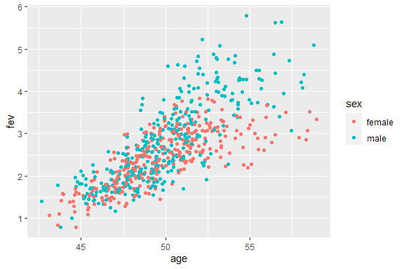

```r
p1 <- data |>
  ggplot(aes(age, fev, color = sex)) +
  geom_jitter(width = 0.5)
p2 <- data |>
  ggplot(aes(height, fev,  color = smoke)) +
  geom_point()

p1
```

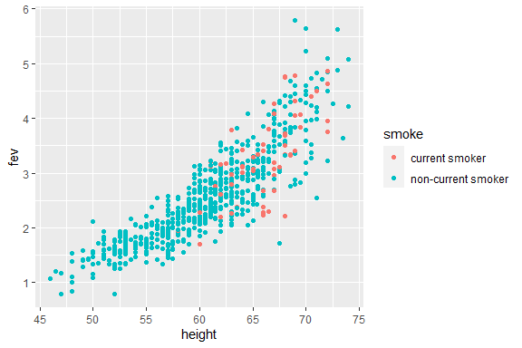

```r
p2
```

Age and height look quite linearly correlated with fev. For sex, maybe males have higher fev. For smoking, we note that the sample size for smokers seems very small.

Below is the plot of each variable against each other. We can see that age and height is highly correlated with a correlation coefficient of 0.792. Including both variables in the model may cause multicolinearity.

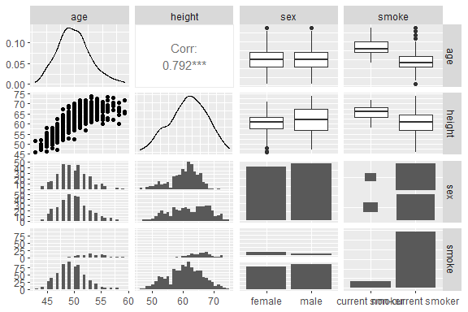

```r
data |>
  select(-fev) |>
  ggpairs()
```

```r
summary(lm(fev ~ height, data = data))
```

```
##
## Call:
## lm(formula = fev ~ height, data = data)
##
## Residuals:
##      Min       1Q   Median       3Q      Max
## -1.75167 -0.26619 -0.00401  0.24474  2.11936
##
## Coefficients:
##              Estimate Std. Error t value Pr(>|t|)
## (Intercept) -5.432679   0.181460  -29.94   <2e-16 ***
## height       0.131976   0.002955   44.66   <2e-16 ***
## ---
## Signif. codes:  0 '***' 0.001 '**' 0.01 '*' 0.05 '.' 0.1 ' ' 1
##
## Residual standard error: 0.4307 on 652 degrees of freedom
## Multiple R-squared:  0.7537, Adjusted R-squared:  0.7533
## F-statistic:  1995 on 1 and 652 DF,  p-value: < 2.2e-16
```

```r
summary(lm(fev ~ age, data = data))
```

```
##
## Call:
## lm(formula = fev ~ age, data = data)
##
## Residuals:
##      Min       1Q   Median       3Q      Max
## -1.57539 -0.34567 -0.04989  0.32124  2.12786
##
## Coefficients:
##              Estimate Std. Error t value Pr(>|t|)
## (Intercept) -8.449991   0.376061  -22.47   <2e-16 ***
## age          0.222041   0.007518   29.53   <2e-16 ***
## ---
## Signif. codes:  0 '***' 0.001 '**' 0.01 '*' 0.05 '.' 0.1 ' ' 1
##
## Residual standard error: 0.5675 on 652 degrees of freedom
## Multiple R-squared:  0.5722, Adjusted R-squared:  0.5716
## F-statistic: 872.2 on 1 and 652 DF,  p-value: < 2.2e-16
```

When we see how much age or height explains the variation in fev, while age only explains about 57%, height explains 75%. We conclude that among these two highly correlated independent variables, height is the better predictor to use in a model. Therefore, we start off with building an additive model that includes everything but age. It explains about 75% of the variance, so it is a pretty good model.

```r
additive_height_smoke_sex <- lm(fev ~ height + smoke + sex, data = data)
summary(additive_height_smoke_sex)
```

```
##
## Call:
## lm(formula = fev ~ height + smoke + sex, data = data)
##
## Residuals:
##      Min       1Q   Median       3Q      Max
## -1.66819 -0.25393  0.00088  0.23749  2.07863
##
## Coefficients:
##                          Estimate Std. Error t value Pr(>|t|)
## (Intercept)             -5.327940   0.209524 -25.429  < 2e-16 ***
## height                   0.129693   0.003106  41.756  < 2e-16 ***
## smokenon-current smoker -0.034138   0.058581  -0.583 0.560265
## sexmale                  0.127643   0.034093   3.744 0.000197 ***
## ---
## Signif. codes:  0 '***' 0.001 '**' 0.01 '*' 0.05 '.' 0.1 ' ' 1
##
## Residual standard error: 0.4268 on 650 degrees of freedom
## Multiple R-squared:  0.7589, Adjusted R-squared:  0.7577
## F-statistic: 681.9 on 3 and 650 DF,  p-value: < 2.2e-16
```

However, this model contains three predictors and it is hard to interpret. Since smoke/non-current smoker is not significant, we consider removing that variable.

```r
data |>
  group_by(smoke) |>
  summarise(num = n())
```

```
## # A tibble: 2 x 2
##   smoke                num
##   <chr>              <int>
## 1 current smoker        65
## 2 non-current smoker   589
```

```r
additive_height_sex <- lm(fev ~ height + sex, data = data)
summary(additive_height_sex)
```

```
##
## Call:
## lm(formula = fev ~ height + sex, data = data)
##
## Residuals:
##     Min      1Q  Median      3Q     Max
## -1.6763 -0.2505  0.0001  0.2347  2.0722
##
## Coefficients:
##              Estimate Std. Error t value Pr(>|t|)
## (Intercept) -5.390263   0.180082 -29.932  < 2e-16 ***
## height       0.130231   0.002964  43.933  < 2e-16 ***
## sexmale      0.125123   0.033801   3.702 0.000232 ***
## ---
## Signif. codes:  0 '***' 0.001 '**' 0.01 '*' 0.05 '.' 0.1 ' ' 1
##
## Residual standard error: 0.4265 on 651 degrees of freedom
## Multiple R-squared:  0.7587, Adjusted R-squared:  0.758
## F-statistic:  1024 on 2 and 651 DF,  p-value: < 2.2e-16
```

So far we have only tested additive model, now we consider interation model as well.

```r
interaction_height_sex <- lm(fev ~ height * sex, data = data)
summary(interaction_height_sex)
```

```
##
## Call:
## lm(formula = fev ~ height * sex, data = data)
##
## Residuals:
##      Min       1Q   Median       3Q      Max
## -1.54654 -0.25282  0.00649  0.25666  2.00491
##
## Coefficients:
##                 Estimate Std. Error t value Pr(>|t|)
## (Intercept)    -4.318219   0.297637 -14.508  < 2e-16 ***
## height          0.112426   0.004928  22.815  < 2e-16 ***
## sexmale        -1.545629   0.373843  -4.134 4.02e-05 ***
## height:sexmale  0.027457   0.006119   4.487 8.54e-06 ***
## ---
## Signif. codes:  0 '***' 0.001 '**' 0.01 '*' 0.05 '.' 0.1 ' ' 1
##
## Residual standard error: 0.4204 on 650 degrees of freedom
## Multiple R-squared:  0.766,  Adjusted R-squared:  0.7649
## F-statistic: 709.2 on 3 and 650 DF,  p-value: < 2.2e-16
```

```r
simple_height <- lm(fev ~ height, data = data)
summary(simple_height)
```

```
##
## Call:
## lm(formula = fev ~ height, data = data)
##
## Residuals:
##      Min       1Q   Median       3Q      Max
## -1.75167 -0.26619 -0.00401  0.24474  2.11936
##
## Coefficients:
##              Estimate Std. Error t value Pr(>|t|)
## (Intercept) -5.432679   0.181460  -29.94   <2e-16 ***
## height       0.131976   0.002955   44.66   <2e-16 ***
## ---
## Signif. codes:  0 '***' 0.001 '**' 0.01 '*' 0.05 '.' 0.1 ' ' 1
##
## Residual standard error: 0.4307 on 652 degrees of freedom
## Multiple R-squared:  0.7537, Adjusted R-squared:  0.7533
## F-statistic:  1995 on 1 and 652 DF,  p-value: < 2.2e-16
```

Both models are significant. Simple model explains 75.3% of the data while interaction model explains 76.4% of the data. From this look of it, the interaction model is better. But since the difference is only subtle, we check the AICc later. We can derive the following equation from the interaction model `interaction_height_sex`:
$$fev = -4.31 + 0.112 \times height - 1.54 \times sex + 0.02 \times sex*height + \epsilon$$

The model makes sense because first, tall people would have bigger lungs to exhale more, and second, sex and height should be correlated. I don’t quite get why the coefficient for sex(male) is negative, but the following visualization of the model shows that males do not necessarily have the larger fev.

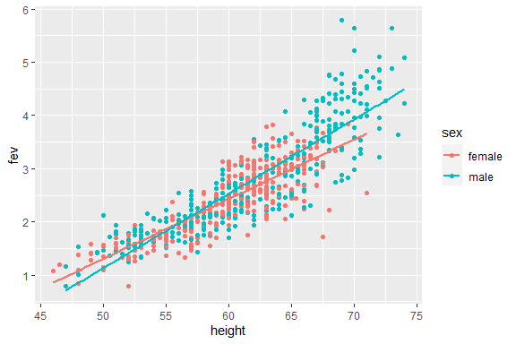

```r
data |>
  ggplot(aes(height, fev, color = sex)) +
  geom_point() +
  geom_smooth(
    formula = y ~ x,
    method = "lm",
    se = FALSE
  )
```

However, when we look at the plot, we cannot help but recognize how scarce females are for over 66. The inequality of sample size by sex for those >66 may be affecting the model. Hence, we build the following model:

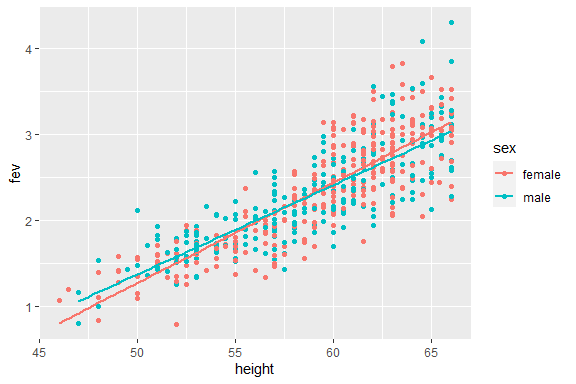

```r
# filter out those who are taller than 66
no_tall_men <- data |>
  filter(height <= 66)
# visualize
ggplot(data = no_tall_men,
       aes(height, fev, color = sex)) +
  geom_point() +
  geom_smooth(
    formula = y ~ x,
    method = "lm",
    se = FALSE
  )
```

```r
interaction_height_sex_66 <- lm(fev ~ height * sex, data = no_tall_men)
summary(interaction_height_sex_66)
```

```
##
## Call:
## lm(formula = fev ~ height * sex, data = no_tall_men)
##
## Residuals:
##      Min       1Q   Median       3Q      Max
## -0.91576 -0.21879 -0.00335  0.21228  1.26800
##
## Coefficients:
##                 Estimate Std. Error t value Pr(>|t|)
## (Intercept)    -4.566980   0.260353 -17.541   <2e-16 ***
## height          0.116756   0.004349  26.845   <2e-16 ***
## sexmale         0.747088   0.380486   1.964   0.0501 .
## height:sexmale -0.012954   0.006409  -2.021   0.0438 *
## ---
## Signif. codes:  0 '***' 0.001 '**' 0.01 '*' 0.05 '.' 0.1 ' ' 1
##
## Residual standard error: 0.338 on 524 degrees of freedom
## Multiple R-squared:  0.7003, Adjusted R-squared:  0.6985
## F-statistic: 408.1 on 3 and 524 DF,  p-value: < 2.2e-16
```

```r
simple_height_66 <- lm(fev ~ height, data = no_tall_men)
summary(simple_height_66)
```

```
##
## Call:
## lm(formula = fev ~ height, data = no_tall_men)
##
## Residuals:
##      Min       1Q   Median       3Q      Max
## -0.87957 -0.21307  0.00543  0.20905  1.20493
##
## Coefficients:
##              Estimate Std. Error t value Pr(>|t|)
## (Intercept) -4.231942   0.189446  -22.34   <2e-16 ***
## height       0.111000   0.003186   34.84   <2e-16 ***
## ---
## Signif. codes:  0 '***' 0.001 '**' 0.01 '*' 0.05 '.' 0.1 ' ' 1
##
## Residual standard error: 0.3388 on 526 degrees of freedom
## Multiple R-squared:  0.6977, Adjusted R-squared:  0.6971
## F-statistic:  1214 on 1 and 526 DF,  p-value: < 2.2e-16
```

The adjusted R-squared value are smaller than the previous two models. We can also compare by AICc.

```r
cat(sprintf(
  "Interaction of height and sex: %g \nSimple height: %g \nInteraction of height and sex under 66: %g \nSimple height under 66: %g",
  AICcmodavg::AICc(interaction_height_sex),
  AICcmodavg::AICc(simple_height),
  AICcmodavg::AICc(interaction_height_sex_66),
  AICcmodavg::AICc(simple_height_66)
))
```

```
## Interaction of height and sex: 728.629
## Simple height: 758.146
## Interaction of height and sex under 66: 358.946
## Simple height under 66: 359.412
```

# survival analysis

refer to week 11 tues lecture

types of censoring 1. right : we may not know when it occurred (the death happened after the collection period), or people dropping out 2. we may not know when it started 3. we only know an even occured in an interval of time

### truncation

1. left truncation if individuals in the population are not observed when the event occures before time t, then the data are said to be left truncated at t individuals with very short survival ecvade sampling - leads to a bias in our analysis
2. right truncation observations with long time to event are excluded from the analysis they are biased towards individuals that have a short time to event

```r
data(ovarian) |>
  print()
```

```
## [1] "ovarian"
```

```r
glimpse(ovarian)
```

```
## Rows: 26
## Columns: 6
## $ futime   <dbl> 59, 115, 156, 421, 431, 448, 464, 475, 477, 563, 638, 744, 76~
## $ fustat   <dbl> 1, 1, 1, 0, 1, 0, 1, 1, 0, 1, 1, 0, 0, 0, 0, 0, 0, 0, 0, 0, 0~
## $ age      <dbl> 72.3315, 74.4932, 66.4658, 53.3644, 50.3397, 56.4301, 56.9370~
## $ resid.ds <dbl> 2, 2, 2, 2, 2, 1, 2, 2, 2, 1, 1, 1, 2, 2, 1, 1, 2, 1, 1, 2, 1~
## $ rx       <dbl> 1, 1, 1, 2, 1, 1, 2, 2, 1, 2, 1, 2, 2, 2, 1, 1, 1, 1, 2, 2, 2~
## $ ecog.ps  <dbl> 1, 1, 2, 1, 1, 2, 2, 2, 1, 2, 2, 1, 2, 1, 1, 2, 2, 1, 1, 1, 2~
```

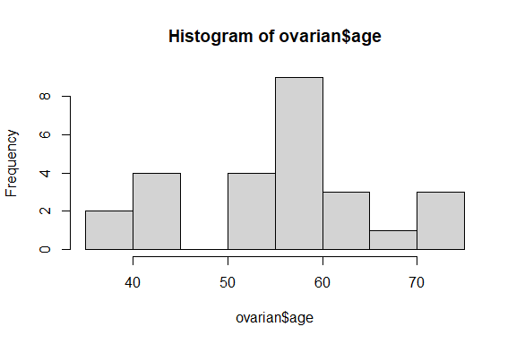

```r
ovarian$rx <- factor(ovarian$rx,
                     levels = c("1", "2"),
                     labels = c("A", "B"))
ovarian$resid.ds <- factor(ovarian$resid.ds,
                           levels = c("1", "2"),
                           labels = c("no", "yes"))
ovarian$ecog.ps <- factor(ovarian$ecog.ps,
                          levels = c("1", "2"),
                          labels = c("good", "bad"))
hist(ovarian$age)
```

```r
ovarian <- ovarian %>% mutate(age_group = ifelse(age >=50, "old", "young"))
ovarian$age_group <- factor(ovarian$age_group)
```

```r
head(ovarian)
```

```
##   futime fustat     age resid.ds rx ecog.ps age_group
## 1     59      1 72.3315      yes  A    good       old
## 2    115      1 74.4932      yes  A    good       old
## 3    156      1 66.4658      yes  A     bad       old
## 4    421      0 53.3644      yes  B    good       old
## 5    431      1 50.3397      yes  A    good       old
## 6    448      0 56.4301       no  A     bad       old
```

```r
surv_object <- Surv(time = ovarian$futime, event = ovarian$fustat)
surv_object
```

```
##  [1]   59   115   156   421+  431   448+  464   475   477+  563   638   744+
## [13]  769+  770+  803+  855+ 1040+ 1106+ 1129+ 1206+ 1227+  268   329   353
## [25]  365   377+
```

## Kaplan-Meier curves

```r
fit<-survfit(surv_object ~ 1, data = ovarian)
summary(fit)
```

```
## Call: survfit(formula = surv_object ~ 1, data = ovarian)
##
##  time n.risk n.event survival std.err lower 95% CI upper 95% CI
##    59     26       1    0.962  0.0377        0.890        1.000
##   115     25       1    0.923  0.0523        0.826        1.000
##   156     24       1    0.885  0.0627        0.770        1.000
##   268     23       1    0.846  0.0708        0.718        0.997
##   329     22       1    0.808  0.0773        0.670        0.974
##   353     21       1    0.769  0.0826        0.623        0.949
##   365     20       1    0.731  0.0870        0.579        0.923
##   431     17       1    0.688  0.0919        0.529        0.894
##   464     15       1    0.642  0.0965        0.478        0.862
##   475     14       1    0.596  0.0999        0.429        0.828
##   563     12       1    0.546  0.1032        0.377        0.791
##   638     11       1    0.497  0.1051        0.328        0.752
```

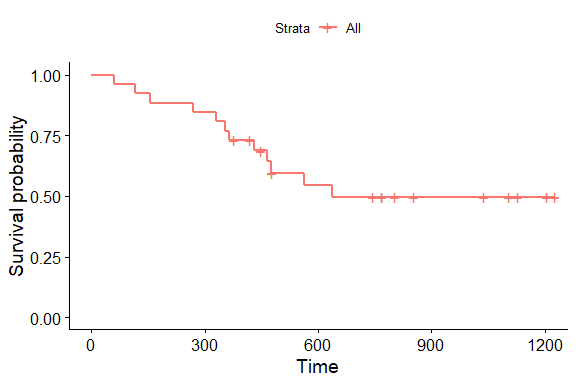

```r
ggsurvplot(fit, data = ovarian,conf.int=FALSE)
```

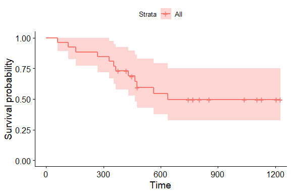

```r
ggsurvplot(fit, data = ovarian)
```

```r
fit1 <- survfit(surv_object ~ rx, data = ovarian)
summary(fit1)
```

```
## Call: survfit(formula = surv_object ~ rx, data = ovarian)
##
##                 rx=A
##  time n.risk n.event survival std.err lower 95% CI upper 95% CI
##    59     13       1    0.923  0.0739        0.789        1.000
##   115     12       1    0.846  0.1001        0.671        1.000
##   156     11       1    0.769  0.1169        0.571        1.000
##   268     10       1    0.692  0.1280        0.482        0.995
##   329      9       1    0.615  0.1349        0.400        0.946
##   431      8       1    0.538  0.1383        0.326        0.891
##   638      5       1    0.431  0.1467        0.221        0.840
##
##                 rx=B
##  time n.risk n.event survival std.err lower 95% CI upper 95% CI
##   353     13       1    0.923  0.0739        0.789        1.000
##   365     12       1    0.846  0.1001        0.671        1.000
##   464      9       1    0.752  0.1256        0.542        1.000
##   475      8       1    0.658  0.1407        0.433        1.000
##   563      7       1    0.564  0.1488        0.336        0.946
```

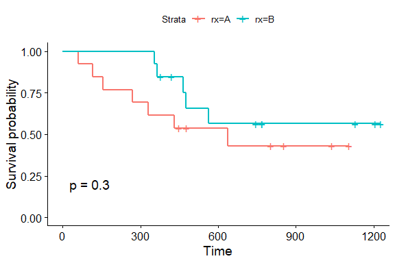

```r
ggsurvplot(fit1, data = ovarian, pval = TRUE)
```

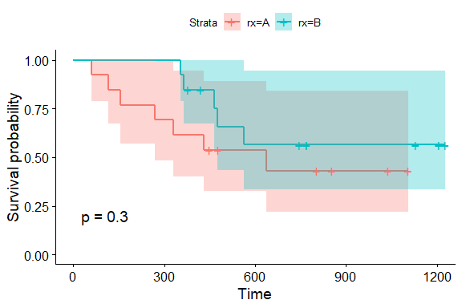

```r
ggsurvplot(fit1, data = ovarian, pval = TRUE, conf.int=TRUE)
```

```r
fit2 <- survfit(surv_object ~ resid.ds, data = ovarian)
summary(fit2)
```

```
## Call: survfit(formula = surv_object ~ resid.ds, data = ovarian)
##
##                 resid.ds=no
##  time n.risk n.event survival std.err lower 95% CI upper 95% CI
##   353     11       1    0.909  0.0867        0.754            1
##   563      8       1    0.795  0.1306        0.577            1
##   638      7       1    0.682  0.1536        0.438            1
##
##                 resid.ds=yes
##  time n.risk n.event survival std.err lower 95% CI upper 95% CI
##    59     15       1    0.933  0.0644        0.815        1.000
##   115     14       1    0.867  0.0878        0.711        1.000
##   156     13       1    0.800  0.1033        0.621        1.000
##   268     12       1    0.733  0.1142        0.540        0.995
##   329     11       1    0.667  0.1217        0.466        0.953
##   365     10       1    0.600  0.1265        0.397        0.907
##   431      8       1    0.525  0.1310        0.322        0.856
##   464      7       1    0.450  0.1321        0.253        0.800
##   475      6       1    0.375  0.1296        0.190        0.738
```

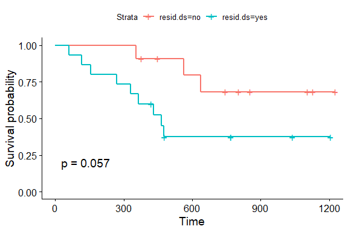

```r
ggsurvplot(fit2, data = ovarian, pval = TRUE)
```

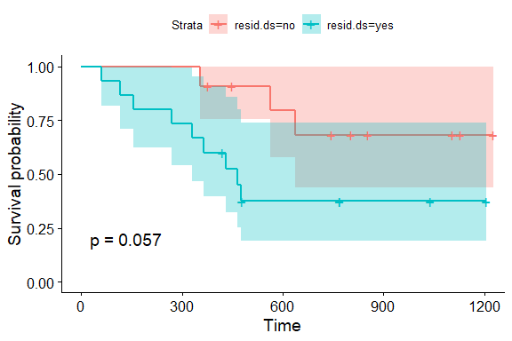

```r
ggsurvplot(fit2, data = ovarian, pval = TRUE, conf.int=TRUE)
```

```r
summary(survfit(Surv(futime, fustat) ~ 1, data = ovarian), times = 365.25)
```

```
## Call: survfit(formula = Surv(futime, fustat) ~ 1, data = ovarian)
##
##  time n.risk n.event survival std.err lower 95% CI upper 95% CI
##   365     19       7    0.731   0.087        0.579        0.923
```

```r
sd <- survdiff(Surv(futime, fustat) ~ resid.ds,
data = ovarian)
sd
```

```
## Call:
## survdiff(formula = Surv(futime, fustat) ~ resid.ds, data = ovarian)
##
##               N Observed Expected (O-E)^2/E (O-E)^2/V
## resid.ds=no  11        3     6.26      1.70      3.62
## resid.ds=yes 15        9     5.74      1.85      3.62
##
##  Chisq= 3.6  on 1 degrees of freedom, p= 0.06
```

```r
1 - pchisq(sd$chisq, length(sd$n) - 1)
```

```
## [1] 0.05697139
```

```r
fit.coxph <- coxph(surv_object ~ rx + resid.ds + age_group + ecog.ps,
                   data = ovarian)

cox.zph(fit.coxph)
```

```
##           chisq df    p
## rx         1.11  1 0.29
## resid.ds   1.51  1 0.22
## age_group  1.06  1 0.30
## ecog.ps    2.15  1 0.14
## GLOBAL     5.31  4 0.26
```

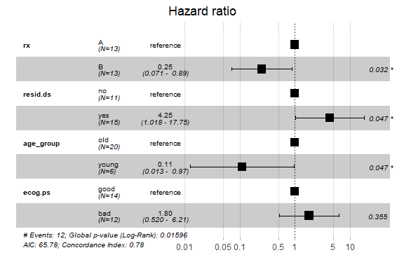

```r
ggforest(fit.coxph, data = ovarian)
```

## KM Survival Analysis cannot use multiple predictors, whereas Cox Regression can

```
KM Survival Analysis can run only on a single binary predictor, whereas Cox Regression can use both continuous and binary predictors. KM is a non-parametric procedure, whereas Cox Regression is a semi-parametric procedure.
```

# Bayes theorem

```r
set.seed(123)
winner = c()
for(i in 1:50000){
  # randomly roll the ball
  p = runif(1, 0,1)
  # sample either Ajay or Nathan
  tmp = sample(c("A", "N"), 8, replace=TRUE, prob=c(p, 1-p))
  if(sum(tmp=="A")==5){
    # Ajay won 5 so far
    a = 5; n = 3
    while(TRUE){
      tmp = sample(c("A", "N"), 1, prob=c(p, 1-p))
      #tmps = c(tmps, tmp)
      # loop
      if(tmp =="A"){ a = a + 1 }
      if(tmp =="N"){ n = n + 1 }
      # until either reaches 6
      if(n == 6 || a == 6){
        break
      }
    }
    if( a == 6 ){
      winner = c(winner, "A")
    }
    if( n == 6 ){
      winner = c(winner, "N")
    }
  }
}
```

```r
table(winner)
```

```
## winner
##    A    N
## 4994  484
```

```r
get_prior = function(vals){
  valspmin = pmin(vals, 1-vals)
  prior = valspmin / sum(valspmin)
  return(data.frame(theta=vals, prior=prior))
}


get_likelihood = function(thetas, successes, failures){
  lvals = dbinom(successes, successes+failures, thetas)

  return(data.frame(theta = thetas, likelihood = lvals))

}

get_posterior = function(likelihood, prior){

  likelihood$likelihood * prior_distribution$prior

  marginal_likelihood = sum(likelihood$likelihood * prior_distribution$prior)

  posterior = (likelihood$likelihood * prior_distribution$prior) / marginal_likelihood

  posterior = data.frame(theta=likelihood$theta, posterior=posterior)
  return(posterior)
}
```

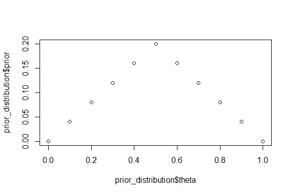

```r
thetas <- seq(0, 1, 0.1)
prior_distribution = get_prior(thetas)
likelihood = get_likelihood(thetas, 1 , 0)
posterior = get_posterior(likelihood, prior_distribution)


thetas <- seq(0, 1, 0.1)
prior_distribution = get_prior(thetas)
likelihood = get_likelihood(thetas, 83 , 17)
posterior = get_posterior(likelihood, prior_distribution)

plot(prior_distribution$theta, prior_distribution$prior)
```

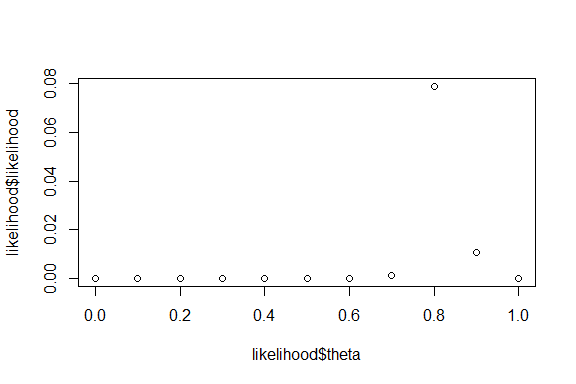

```r
plot(likelihood$theta, likelihood$likelihood)
```

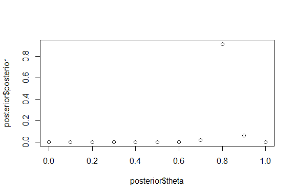

```r
plot(posterior$theta, posterior$posterior)
```

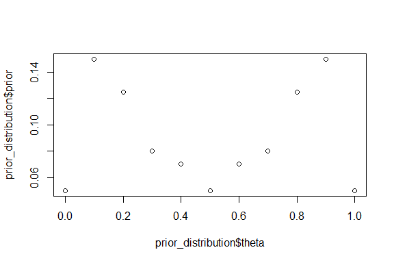

```r
get_biased_prior = function(vals){
  return(data.frame(theta=vals, prior=c(0.05, 0.15, 0.125,
                                        0.08, 0.07, 0.05,
                                        0.07, 0.08, 0.125,
                                        0.15, 0.05)))
}

thetas <- seq(0, 1, 0.1)
prior_distribution = get_biased_prior(thetas)
likelihood = get_likelihood(thetas, 1 , 0)
posterior = get_posterior(likelihood, prior_distribution)

plot(prior_distribution$theta, prior_distribution$prior)
```

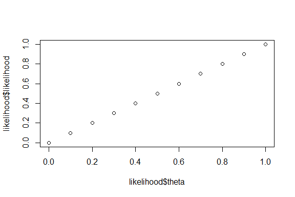

```r
plot(likelihood$theta, likelihood$likelihood)
```

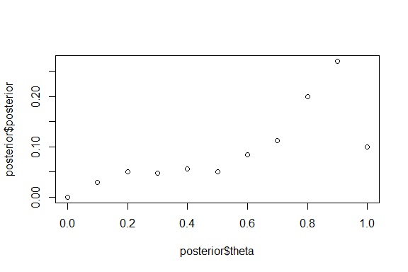

```r
plot(posterior$theta, posterior$posterior)
```

## model selection

1. forward selection

starts with no predictors in the model

iteratively adds the predictors which contribute the most to explaining the dependent variable

stops when the improvement is no longer statistically significant

2. backward selection

starts with all predictors in the model

remove the predictors which contribute the least to explaining the dependent variable

stops when the improvement is no longer statistically significant

3. stepwise selection

starts with no predictors in the model

a combination of forward and backward selections

4. all subsets

test everything

## odds

$$\frac{p}{1-p}$$

[^1]: Quote from https://www.healthline.com/health/serum-cholesterol, accessed on Feb 21st 2022.
[^2]: Quote from https://www.dovepress.com/new-developments-in-the-treatment-of-primary-biliary-cholangitis-role--peer-reviewed-fulltext-article-TCRM, accessed on Feb 21 2022.
[^3]: “How to Perform Post-Hoc Pairwise Comparisons in R”https://www.statology.org/pairwise-comparison-in-r/